# Introduction to R for Data Analysis

Muhammad Hilmi Abdul Majid

## Introduction

In the previous topic, we have discussed about the importance of data analysis and visualization. We have also briefly touched on the tools that can be used for it. One such tool is the R programming language. Here, we will start by introducing R and RStudio which will be used extensively as we go through with the course.

## Introduction to R

R is a powerful and versatile programming language and software environment specifically designed for statistical computing and data visualization. It is widely used by statisticians, data scientists, researchers, and analysts for exploring, modeling, and visualizing data.

### A brief history of R

R was developed in the early 1990s by Ross Ihaka and Robert Gentleman at the University of Auckland, New Zealand. It was inspired by the S programming language, which was created at Bell Laboratories. The goal of R was to provide a free, open-source alternative to S, while maintaining its flexibility and power. Over the years, R has grown into a vibrant ecosystem supported by a large, active community of developers and users. This growth has been fueled by its accessibility and the continuous addition of new tools and functionalities.

### Key features of R

R stands out as a comprehensive tool for data analysis and visualization due to several key features:

- **Open Source and Free:** R is open-source software, which means it is free to use, modify, and distribute. This has made it highly accessible to individuals and organizations worldwide.
- **Comprehensive Statistical Support:** R offers a vast array of built-in statistical methods, from basic descriptive statistics to advanced techniques like machine learning and time-series analysis.
- **Data Visualization:** R excels at creating high-quality graphics and data visualizations. Libraries such as `ggplot2` provide unparalleled flexibility for customizing plots.
- **Extensible Through Packages:** The R ecosystem includes thousands of packages available through repositories like CRAN (Comprehensive R Archive Network) and Bioconductor. These packages extend R’s functionality to specialized areas such as bioinformatics, spatial data analysis, and more.
- **Cross-Platform Compatibility:** R runs on multiple platforms, including Windows, macOS, and Linux, ensuring that it is accessible to users regardless of their operating system.
- **Active Community:** The R community contributes to its growth by developing packages, writing tutorials, and participating in forums. Resources such as R-bloggers, Stack Overflow, and CRAN Task Views provide valuable support.

### Why use R?

There are several compelling reasons to learn and use R for data analysis:

- **Rich Ecosystem:** With its extensive libraries and packages, R can handle tasks ranging from data cleaning and manipulation to complex statistical modeling and machine learning.
- **Customizability:** R scripts and functions are highly customizable, enabling users to tailor solutions to their specific needs.
- **Reproducibility:** R facilitates reproducible research through tools like R Markdown and Shiny, which allow users to create dynamic reports, dashboards, and applications.
- **Community Support:** The active and collaborative R community ensures that users can find help, share knowledge, and stay updated with the latest developments.

### Comparing R and python for data analysis and visualization

R and Python are two of the most popular programming languages for data analysis and visualization. While both are powerful tools, they have distinct features, strengths, and weaknesses that make them suitable for different types of tasks and users.

Strengths of R:

- **Statistical Analysis:** R was specifically designed for statistical computing, making it the go-to language for statisticians and researchers. It provides a vast array of built-in statistical methods and specialized libraries.
- **Data Visualization:** R excels in creating high-quality visualizations with packages like `ggplot2`, `lattice`, and `shiny`. It offers unparalleled customization and aesthetic options for plots.
- **Domain-Specific Libraries:** R’s package ecosystem, including Bioconductor, caters to niche fields such as genomics, clinical trials, and epidemiology.
- **Interactive Reporting:** Tools like R Markdown and Shiny make it easy to create dynamic reports and dashboards, enabling reproducibility and interactivity.

Strengths of Python:

- **General-Purpose Programming:** Python is a versatile, general-purpose language that is not limited to data analysis. It can be used for web development, automation, machine learning, and more.
- **Machine Learning and AI:** Python’s libraries like `scikit-learn`, `TensorFlow`, and `PyTorch` make it a top choice for machine learning, deep learning, and artificial intelligence projects.
- **Ease of Learning:** Python’s syntax is intuitive and beginner-friendly, making it an ideal choice for those new to programming.
- **Data Manipulation:** Libraries like `pandas` and `NumPy` offer powerful tools for handling and manipulating large datasets efficiently.
- **Integration:** Python integrates seamlessly with other technologies and languages, making it suitable for production-level applications.

Both R and Python are exceptional tools for data analysis and visualization. For statisticians and visualization enthusiasts, R’s specialized capabilities are unmatched. On the other hand, Python’s versatility and integration make it ideal for machine learning and broader applications. Understanding the strengths and use cases of both languages will empower you to select the right tool for your data-driven endeavors.

However, for a (future) data analyst and data scientist, it is better for you to learn both R and python. You may not have to be proficient in both, and you may have preference on using one over the other. But you should at least be familiar with the programming language.

### Getting started with R

To begin using R, you need to install two key components:

1. **Base-R:** This is the core software environment, which includes essential tools and libraries for statistical analysis.
2. **RStudio:** A popular integrated development environment (IDE) for R that enhances usability with features like syntax highlighting, code completion, and integrated plotting.

You can download R from the official CRAN website (https://cran.r-project.org) and RStudio from its official site (https://posit.co/download/rstudio-desktop/). To install RStudio, you should first install R. Once installed, you will have a robust environment ready to tackle any data analysis challenge.

Note that using RStudio is not necessary. However, RStudio offers a much better experience for beginner and veteran users. Although RStudio is not affiliated with R, RStudio is freely available to everyone with some paid options for enterprise. There is no reason not to use RStudio.

After installing both R and RStudio, open RStudio. Then, from the menu, click *File* -> *New File* ->*R Script* or press CTRL+Shift+N to create a new R script in the editor pane.

[figure not shown]

RStudio default interface

The layout of RStudio is divided into four panels. By default, at the top left, we have the *Source* pane, *Console* pane at the bottom left, *Environment, History, Connections* at the top right, and *Files, Plots, Packages, Help, Viewer* at the bottom right. If you wish to edit the layout, you can go to *Tools* -> *Global Options* -> *Pane Layout*.

We can write down R codes in the console. But editing huge R scripts in the console is not efficient and difficult. Thus, we can use the editor in the *Source* pane to write long R scripts and we can choose to run them line-by-line or all of them together.

### Working with R scripts

When using R (and R Studio), you have the option to either input your command or code in the console, or write them in the script editor. It is advised that you use the script editor instead of the console, unless you just want to run a quick code.

To create a new script file, go to the “File” menu, click “New File” and choose “R Script”. Alternatively, you can use the keyboard shortcut CTRL+SHIFT+N (if you are using Windows with default keyboard shortcut setting). You can then save the scrip file as a .R extension if you want to edit or run the code again at another time.

[figure not shown]

Creating a new R script file

[figure not shown]

Click the “**Run**” button to run codes

## R Basics

### Basic calculations in R

R can be used like an advanced calculator. For example, you can input these lines in the console (or in the script editor) and run it and R will give you the results.

```r
3+2
```

```
## [1] 5
```

```r
3*5
```

```
## [1] 15
```

```r
7/3
```

```
## [1] 2.333333
```

Notice that multiplication requires the use of `*`, and that division gives results in decimal numbers.

Note also that the `[1]` in front of the output can be ignored. The `[1]` is used to show the position of the value. For example, if we were to list down all even numbers from 2 to 100 as the code below, we can see the second and third lines in the output with different number in the `[]` for the position of the value in the line.

```r
seq(from = 2, to = 100, by = 2)
```

```
##  [1]   2   4   6   8  10  12  14  16  18  20  22  24  26  28  30  32  34  36  38
## [20]  40  42  44  46  48  50  52  54  56  58  60  62  64  66  68  70  72  74  76
## [39]  78  80  82  84  86  88  90  92  94  96  98 100
```

Here are some basic operations you can use in R.

Basic operations in R.

| Operations | Operator/function | Example Input | Example Output |
| --- | --- | --- | --- |
| Addition | `+` | `10+2` | `12` |
| Substraction | `-` | `9-3` | `6` |
| Multiplication | `*` | `5*5` | `25` |
| Division | `/` | `6/3` | `2` |
| Power | `^` | `5^2` | `25` |
| Square root | `sqrt()` | `sqrt(4)` | `2` |
| Exponent, $e^x$ | `exp()` | `exp(1)` | `2.718282` |
| Log | `log()` | `log(exp(1))` | `1` |
| Absolute | `abs()` | `abs(-10)` | `10` |

There are also trigonometric operators such as `sin()`, `cos()`, or `tan()` and Boolean or logical operators such as `&` (and), `|` (or), `==` (equals) or `!` (not).

### Storing a value to a variable

Oftentimes, it is easier to assign name or variable to a value. Then, any calculation can be done using the newly assigned variable. Note that the upper or lower case in the name of the variable matters.

To assign variable to a value, you can either use

- `variable = value`
- `variable <- value`
- `value -> variable`

However, the second command `variable <- value` is the most commonly used way to assign value to a variable.

Example:

```r
x = 350
x
```

```
## [1] 350
```

```r
y <- 100
y
```

```
## [1] 100
```

```r
50 -> z
z
```

```
## [1] 50
```

```r
x+y
```

```
## [1] 450
```

```r
y/z
```

```
## [1] 2
```

```r
sqrt(y)
```

```
## [1] 10
```

### Working with vectors

To work with vectors, you will need to use the `c()` function (short for concatenate). For example if $x$ is a vector $(1,2,3)$, you need to write down `x <- c(1,2,3)`. Then, you can use basic operators as used in previous examples. Note however that the basic operators are component-wise

```r
x <- c(1,2,3)
y <- c(4,5,6)
x*2
```

```
## [1] 2 4 6
```

```r
x+y
```

```
## [1] 5 7 9
```

```r
x*y
```

```
## [1]  4 10 18
```

To select an element out of a vector, we use the `[]` notation. For example, if we want to call out the 3rd element of a vector $x$, we use `x[3]`.

```r
x <- c(3,2,5,6,3)
x[3]
```

```
## [1] 5
```

```r
x[5]
```

```
## [1] 3
```

```r
x[6]
```

```
## [1] NA
```

You can also use vectors to select multiple elements of a vector using `x[c(???)]`.

```r
x <- c(3,2,5,6,3)
x[c(3,5,4)]
```

```
## [1] 5 3 6
```

If you have a condition with `TRUE` or `FALSE` value, you can select elements that fit the condition using `x[conditions]`.

```r
x <- c(3,2,5,6,3)
x[x>3]
```

```
## [1] 5 6
```

```r
x[x<=3]
```

```
## [1] 3 2 3
```

Here are some vector operations you can use in R using `x <- c(1,5,4)`.

Vector operations in R

| Operation | Operator/function | Example Input | Example Output |
| --- | --- | --- | --- |
| Summation | `sum()` | `sum(x)` | `10` |
| Product | `prod()` | `prod(x)` | `20` |
| Maximum | `max()` | `max(x)` | `5` |
| Minimum | `min()` | `min(x)` | `1` |
| Length | `length()` | `length(x)` | `3` |
| Which of the element is max | `which.max()` | `which.max(x)` | `2` |
| Which of the element is min | `which.min()` | `which.min(x)` | `1` |
| Sort | `sort()` | `sort(x)` | `1 4 5` |

In many cases, we want vectors to simply be integers between $a$ and $b$. To do that, we can use `a:b` to list down all integers between the two numbers.

Alternatively, using `seq()` function allows us to create a sequence of numbers.

- `seq(1, 10, by=0.5)` gives a sequence from 1 to 10 where the difference between two consecutive numbers is 0.5
- `seq(1, 10, length.out=5)` gives a sequence from 1 to 10 where the length of the sequence is 5.

```r
3:6
```

```
## [1] 3 4 5 6
```

```r
7:2
```

```
## [1] 7 6 5 4 3 2
```

```r
seq(3, 5, by=0.3)
```

```
## [1] 3.0 3.3 3.6 3.9 4.2 4.5 4.8
```

```r
seq(3, 4, length.out=6)
```

```
## [1] 3.0 3.2 3.4 3.6 3.8 4.0
```

```r
seq(3, 4, length.out=5)
```

```
## [1] 3.00 3.25 3.50 3.75 4.00
```

### Working directory

The working directory is the directory in which you are working in. For example, you can run or save files that are in the working directory without specifying the full path.

To check your current working directory, use the function `getwd()`. To change your working directory, use the function `setwd(directory_path)`. Running `setwd(choose.dir())` allows you to select the directory interactively. Alternatively, you can use the *Files* pane in RStudio to set the working directory.

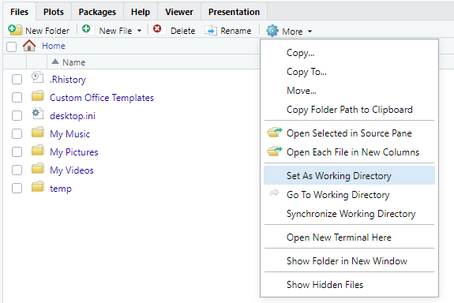

Changing working directory using RStudio

### Libraries

Packages are a collection of codes and functions written by a third party and is not included in the base R. They are useful because R users can share their codes to the public, and the public can use it freely.

To install and download a package from CRAN (Comprehensive R Archive Network), use the function `install.packages("package_name")`. Then to load the package, use the function `library(package_name)`.

In this course, two main packages that we will be using is `ggplot2` for data visualization and `dplyr` for data manipulation. You can install both of these using the code below.

```r
install.packages("ggplot2")
install.packages("dplyr")
library(ggplot2)
library(dplyr)
```

Note that you only need to run the command `install.packages()` once to download the package from the internet. However the command `library()` needs to be run everytime you restart R, if you want to use codes and functions in the package.

### Functions in R

Every function in R has three basic parts: its name, the set of arguments (or parameters), and the body of code.

When running a function, you can specify the argument by writing `function_name(argument_name = value)` or just setting `function_name(value)`. If you do not specify the argument name, then R will specify the argument by position. Additionally, the argument takes the default value if it is not specified.

For example, suppose we have: `fn_name(arg1 = value1, arg2 = value2)`. Then

- The name of the function is `fn_name`.
- There are two arguments, `arg1` and `arg2`.
- Default value for `arg1` is `value1`. Default value for `arg2` is `value2`.
- Running `fn_name()` without specifying the argument is equivalent to running `fn_name(arg1=value1, arg2=value2)`.
- Running `fn_name(a)` is equivalent to `fn_name(arg1=a, arg2=value2)`.
- Running `fn_name(a, b)` is equivalent to `fn_name(arg1=a, arg2=b)`.
- Running `fn_name(arg2=a, arg1=b)` is equivalent to `fn_name(arg1=b, arg2=a)` or `fn_name(b, a)`.

### Comments

In R, you can add the `#` sign to start a comment. Any code in the line following the `#` sign will not be run by R.

For example, in the code below, `x <- 20` will not run and will be ignored by R.

```r
x <- 10    # This will run
#x <- 20   # This will not run
x
```

```
## [1] 10
```

### Help and documentations

For built-in functions (or functions from packages), using `help(function_name)` or `?function_name` will give the help page and documentation of the function which includes:

- Description of the function
- Function arguments and its default value
- Value the function returns.

Try running `help(sum)` or `?sum` to see the help page for the function.

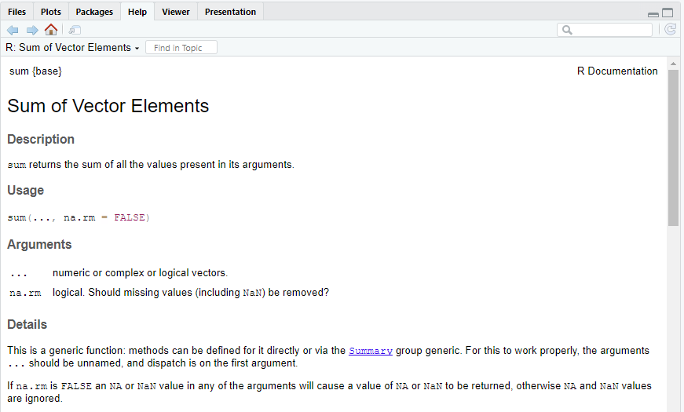

Description of the summation function

Packages hosted in CRAN also require developers to upload documentation and manual for the package. For example, here is the CRAN site for `ggplot2`: https://cran.r-project.org/web/packages/ggplot2/index.html. Notice that there is a link for a PDF document for the package manual.

If you have trouble with your code or R in general, a good advice is to search for the solution on the internet. You would be surprise by the amount of support you can find, especially on site such as https://stackoverflow.com/.

### More on R

If you wish to learn more on R, there are plenty of available resources you can find on the internet. Here are some of our recommendations:

- **A (very) short introduction to R** note written by Paul Torfs and Claudia Brauer is a good introduction to R for beginners that is available freely online (https://cran.r-project.org/doc/contrib/Torfs+Brauer-Short-R-Intro.pdf). It touches on the basic use of R including the things we have covered in this topic and more.
- **Bookdown** (https://bookdown.org/) is an open-source R package for writing books using R Markdown. They also host several books freely available online including **R Programming for Data Science** by Roger D. Peng, **R for Data Science** by Hadley Wickham and Garrent Grolemund, and **Hands-On Programming with R** by Garrent Grolemund. As mentioned, these books are free and they provide useful notes on using R.

## Conclusion

In this topic, we have briefly discussed about the importance of data analysis and visualization and the R programming language and RStudio. We have also briefly discuss about how to perform basic operations using R, which we will use extensively. In the next topic, we will talk about preparing, cleaning, and manipulating data using R and the `dplyr` package.